# StatDescript

StatDescript Yuxuan Li 9/2/2019

```r
summary(bnb.data)
```

```
##        X           log_price         property_type
##  Min.   :    1   Min.   :0.000   Apartment  :23737
##  1st Qu.:18602   1st Qu.:4.317   House      : 8049
##  Median :37011   Median :4.718   Condominium: 1298
##  Mean   :37081   Mean   :4.783   Townhouse  :  820
##  3rd Qu.:55712   3rd Qu.:5.220   Loft       :  616
##  Max.   :74111   Max.   :7.600   Other      :  289
##                                  (Other)    : 1191
##            room_type      amenities          accommodates
##  Entire home/apt:20001   Length:36000       Min.   : 1.000
##  Private room   :14928   Class :character   1st Qu.: 2.000
##  Shared room    : 1071   Mode  :character   Median : 2.000
##                                             Mean   : 3.155
##                                             3rd Qu.: 4.000
##                                             Max.   :16.000
##
##    bathrooms             bed_type          cancellation_policy
##  Min.   :0.00   Airbed       :  245   flexible       :10971
##  1st Qu.:1.00   Couch        :  136   moderate       : 9221
##  Median :1.00   Futon        :  392   strict         :15755
##  Mean   :1.24   Pull-out Sofa:  265   super_strict_30:   45
##  3rd Qu.:1.00   Real Bed     :34962   super_strict_60:    8
##  Max.   :8.00
##  NA's   :95
##  cleaning_fee         city        first_review        host_has_profile_pic
##  Mode :logical   Boston : 1686   Min.   :2009-01-20    :   91
##  FALSE:9668      Chicago: 1800   1st Qu.:2015-06-27   f:  108
##  TRUE :26332     DC     : 2788   Median :2016-05-23   t:35801
##                  LA     :10966   Mean   :2016-01-13
##                  NYC    :15629   3rd Qu.:2017-01-02
##                  SF     : 3131   Max.   :2017-10-03
##                                  NA's   :7717
##  host_identity_verified host_response_rate   host_since
##   :   91                Min.   :0.000      Min.   :2008-03-04
##  f:11828                1st Qu.:1.000      1st Qu.:2013-04-24
##  t:24081                Median :1.000      Median :2014-09-30
##                         Mean   :0.943      Mean   :2014-07-21
##                         3rd Qu.:1.000      3rd Qu.:2015-12-22
##                         Max.   :1.000      Max.   :2017-10-04
##                         NA's   :8983       NA's   :91
```

[output cut: 33 more lines]

```
##  Mode :logical   Mode :logical   Mode :logical   Mode :logical
##  FALSE:3179      FALSE:3407      FALSE:14965     FALSE:15213
##  TRUE :32821     TRUE :32593     TRUE :21035     TRUE :20787
##
##
##
##
##  am_Parking      am_Shampoo      am_Essentials   has_review
##  Mode :logical   Mode :logical   Mode :logical   0: 7692
##  FALSE:24594     FALSE:11926     FALSE:4901      1:28308
##  TRUE :11406     TRUE :24074     TRUE :31099
##
##
##
##
```

```r
num.data <- bnb.data
```

# 1.Number of amenity

First of first, take a look of numeric characters on price, including the numbers of **accomodates, beds, bedrooms, and bathrooms**. Do scatter plot and violin plot of (log-)price on each varaiable.

165 observations removed due to NA’s.

### Conclusion:

- The log price and those numbers have roughly positive relationship (sort of sigmoid). I think quadratic term might be necessary in linear regression.
- Further controls are needed.

```r
amen.data <- bnb.data %>%
  select(price, log_price, accommodates, beds, bedrooms, bathrooms, has_review) %>%
  na.omit() # 35835 obs

summary(amen.data)
```

```
##      price          log_price      accommodates         beds
##  Min.   :   1.0   Min.   :0.000   Min.   : 1.000   Min.   : 0.000
##  1st Qu.:  75.0   1st Qu.:4.317   1st Qu.: 2.000   1st Qu.: 1.000
##  Median : 113.0   Median :4.727   Median : 2.000   Median : 1.000
##  Mean   : 161.2   Mean   :4.784   Mean   : 3.159   Mean   : 1.715
##  3rd Qu.: 185.0   3rd Qu.:5.220   3rd Qu.: 4.000   3rd Qu.: 2.000
##  Max.   :1999.0   Max.   :7.600   Max.   :16.000   Max.   :16.000
##     bedrooms       bathrooms    has_review
##  Min.   : 0.00   Min.   :0.00   0: 7652
##  1st Qu.: 1.00   1st Qu.:1.00   1:28183
##  Median : 1.00   Median :1.00
##  Mean   : 1.27   Mean   :1.24
##  3rd Qu.: 1.00   3rd Qu.:1.00
##  Max.   :10.00   Max.   :8.00
```

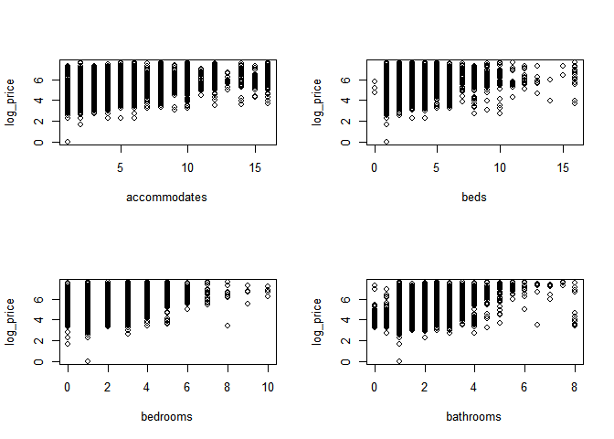

```r
# log price to ammenity numbers
par(mfrow = c(2, 2))
for (i in 3:6){
  plot(amen.data[,2] ~ amen.data[,i],
        xlab = colnames(amen.data)[i], ylab = colnames(amen.data)[2])
}
```

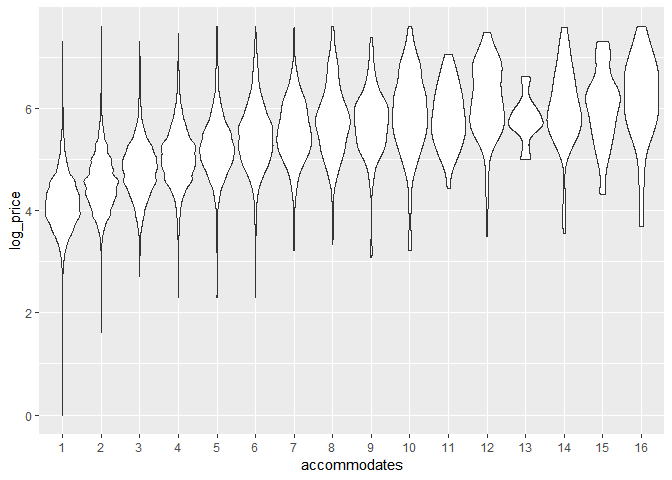

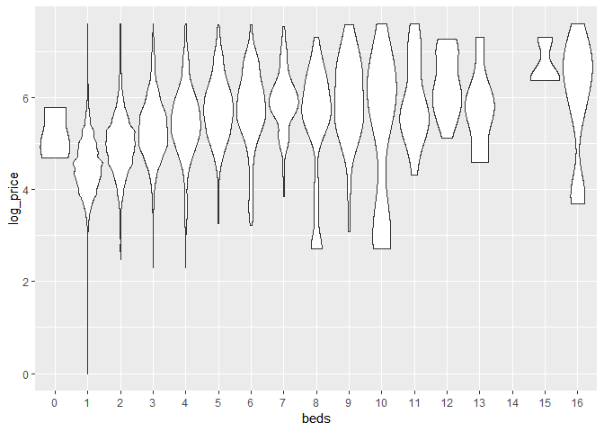

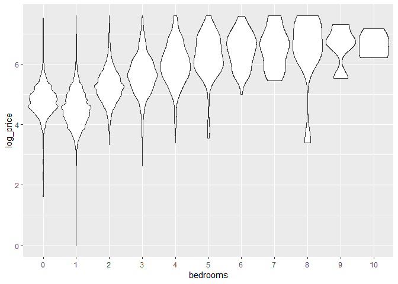

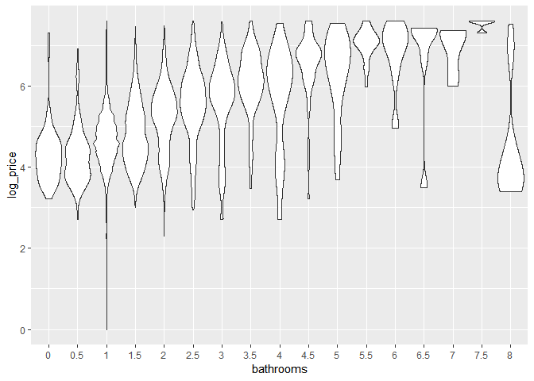

```r
# better(?) version
for (i in 3:6){
  p <- ggplot(amen.data,
              aes(x = as.factor(amen.data[,i]), y = amen.data[,2]),
                  fill = has_review) +
    geom_violin(scale = "width") +
    xlab(colnames(amen.data)[i]) +
    ylab(colnames(amen.data)[2])

  print(p)
}
```

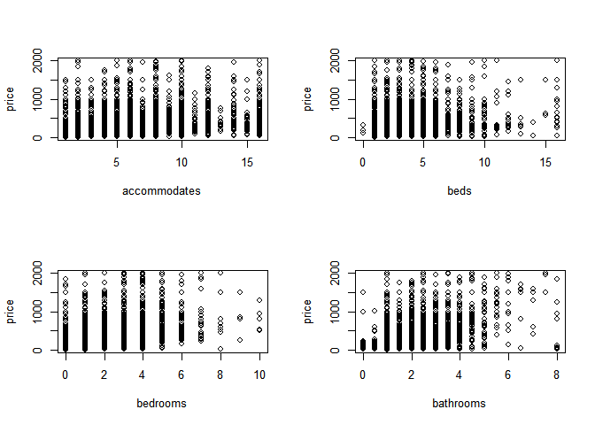

```r
# price to ammenity numbers
par(mfrow = c(2, 2))
for (i in 3:6){
plot(amen.data[,1] ~ amen.data[,i],
xlab = colnames(amen.data)[i], ylab = colnames(amen.data)[1])
}
```

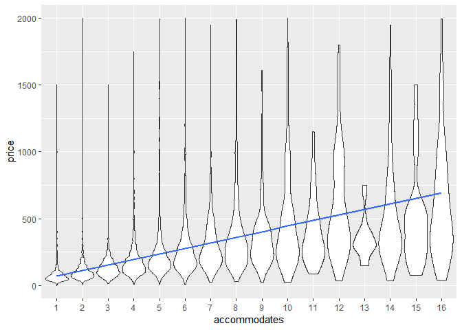

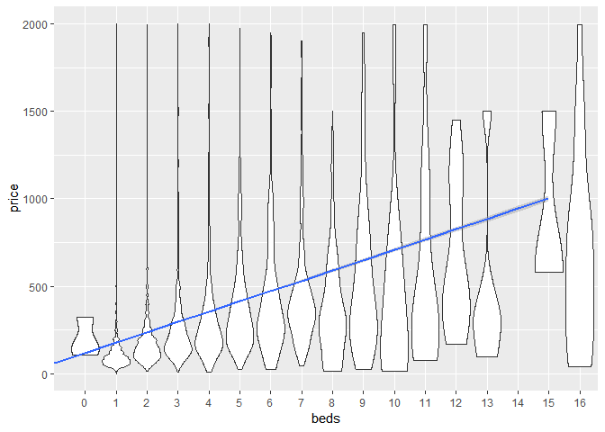

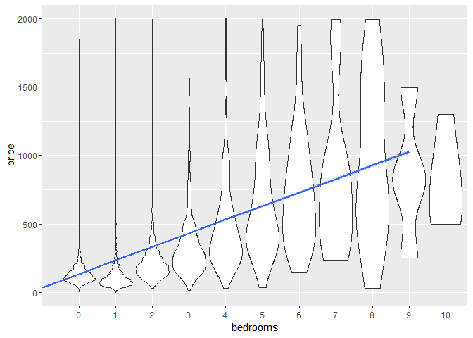

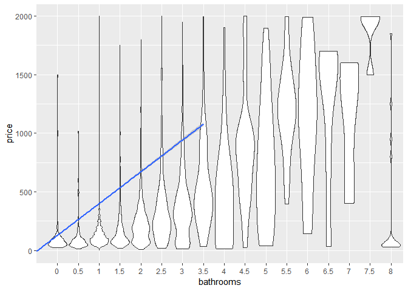

```r
# better(?) version
for (i in 3:6){
  p <- ggplot(amen.data,aes(x = as.factor(amen.data[,i]), y = amen.data[,1])) +
    geom_violin(scale = "width") +
    geom_smooth(aes(x = amen.data[,i], y = amen.data[,1]),method = "lm") +
    xlab(colnames(amen.data)[i]) +
    ylab(colnames(amen.data)[1])

  print(p)
}
```

# 2. Hosts and Reviews

Now consider numerical variables **host_response_rate, number_of_reviews, review_scores_rating**, and logical variables **host_has_profile_pic** and **host_identity_verified**.

Note: if No first_review -> number_of_reviews = 0 -> review_scores_rating is NA. -> No host_response_rate (roughly)

```r
hore.data <- bnb.data %>%
  select(price, log_price,
         host_response_rate, number_of_reviews, review_scores_rating,
         host_has_profile_pic, host_identity_verified) %>%
  mutate(review_scores_rating)
summary(hore.data)
```

```
##      price          log_price     host_response_rate number_of_reviews
##  Min.   :   1.0   Min.   :0.000   Min.   :0.000      Min.   :  0.00
##  1st Qu.:  75.0   1st Qu.:4.317   1st Qu.:1.000      1st Qu.:  1.00
##  Median : 112.0   Median :4.718   Median :1.000      Median :  6.00
##  Mean   : 161.1   Mean   :4.783   Mean   :0.943      Mean   : 20.73
##  3rd Qu.: 185.0   3rd Qu.:5.220   3rd Qu.:1.000      3rd Qu.: 23.00
##  Max.   :1999.0   Max.   :7.600   Max.   :1.000      Max.   :532.00
##                                   NA's   :8983
##  review_scores_rating host_has_profile_pic host_identity_verified
##  Min.   : 20.0         :   91               :   91
##  1st Qu.: 92.0        f:  108              f:11828
##  Median : 96.0        t:35801              t:24081
##  Mean   : 94.1
##  3rd Qu.:100.0
##  Max.   :100.0
##  NA's   :8143
```

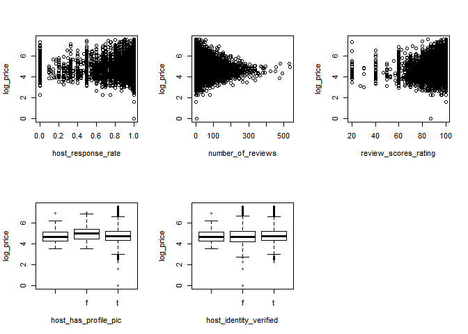

```r
# log price to host and reviews
par(mfrow = c(2, 3))
for (i in 3:7){
  plot(hore.data[,2] ~ hore.data[,i],
        xlab = colnames(hore.data)[i], ylab = colnames(hore.data)[2])
}

# price to host and reviews
par(mfrow = c(2, 3))
```

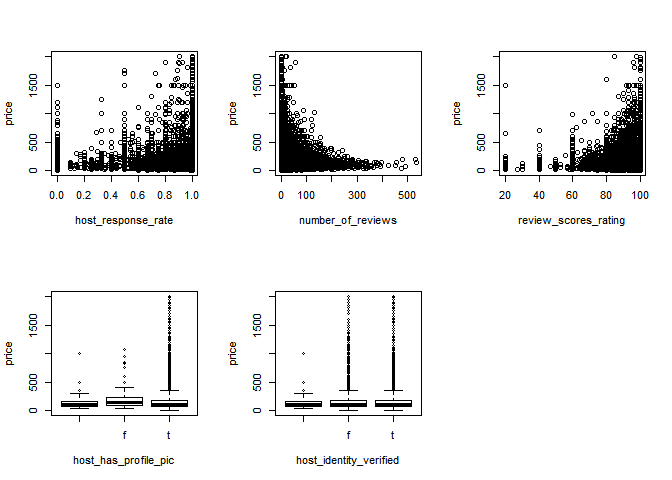

```r
for (i in 3:7){
  plot(hore.data[,1] ~ hore.data[,i],
        xlab = colnames(hore.data)[i], ylab = colnames(hore.data)[1])
}
```

# 3. Has Review

```r
summary(bnb.data$has_review)
```

```
##     0     1
##  7692 28308
```

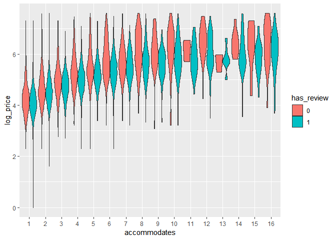

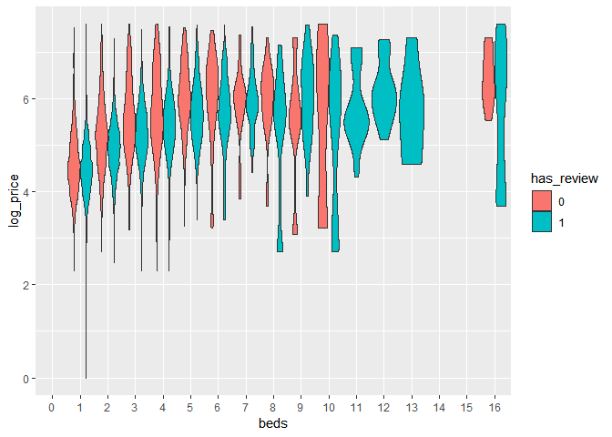

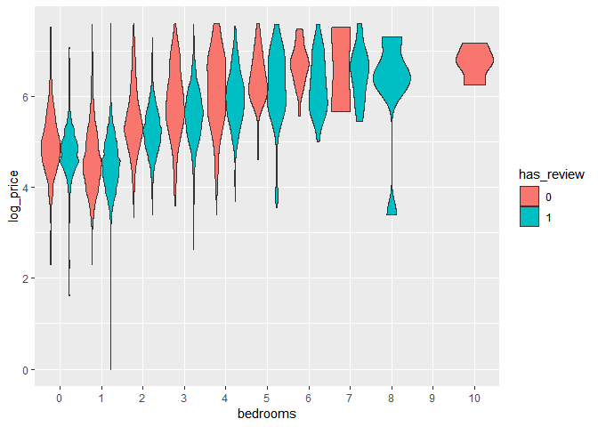

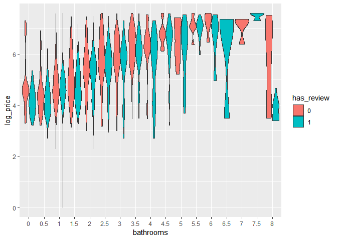

```r
for (i in 3:6){
  p <- ggplot(amen.data,
              aes(x = as.factor(amen.data[,i]), y = amen.data[,2])) +
    geom_violin(aes(x = as.factor(amen.data[,i]), y = amen.data[,2],
                    fill = has_review),
                scale = "width") +
    xlab(colnames(amen.data)[i]) +
    ylab(colnames(amen.data)[2])

  print(p)
}
```

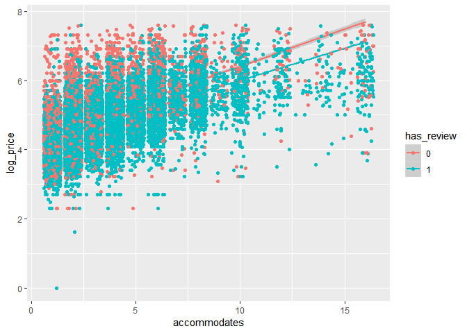

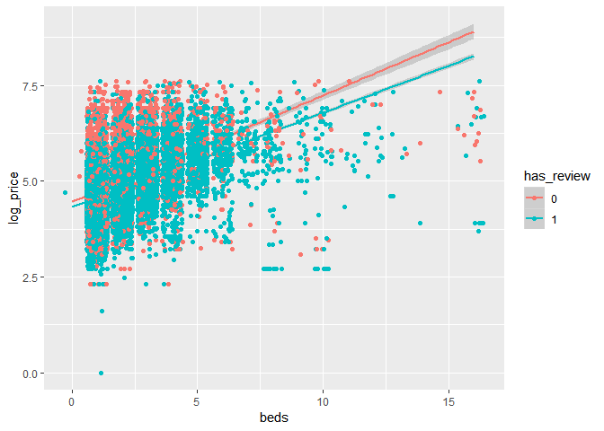

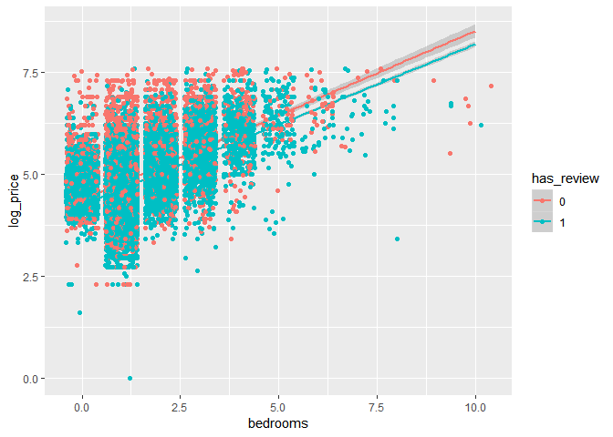

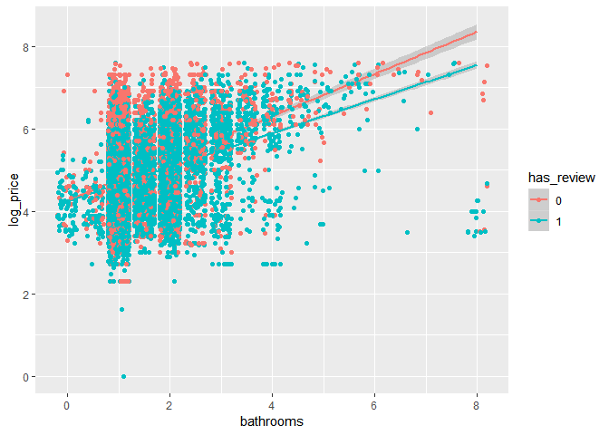

```r
for (i in 3:6){
  p <- ggplot(amen.data,
              aes(x = amen.data[,i], y = amen.data[,2], color = has_review)) +
    geom_smooth(method = lm) +
    geom_jitter() +
    xlab(colnames(amen.data)[i]) +
    ylab(colnames(amen.data)[2])

  print(p)
}
```

# 4. Do something extra

Our prior insights suggests that review_rate should have some relationship, which was not obvious in the scatter plot. So let do some transformation.

Assume price and bedrooms have linear relationship. Plot (log_)price_per_bdrm on rate. This graph, of cource, only apply to those obs with at least one review, and at least one bdrm.

The result suggests that this section is totally redundant.

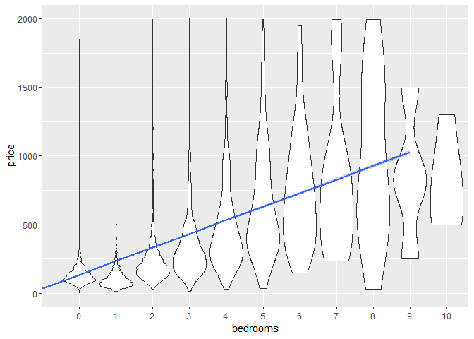

```r
# recall the graph in section 1 to see "linear" relationship of price and bdrm
i <- 5
ggplot(amen.data,aes(x = as.factor(amen.data[,i]), y = amen.data[,1])) +
    geom_violin(scale = "width") +
    geom_smooth(aes(x = amen.data[,i], y = amen.data[,1]),method = "lm") +
    xlab(colnames(amen.data)[i]) +
    ylab(colnames(amen.data)[1])
```

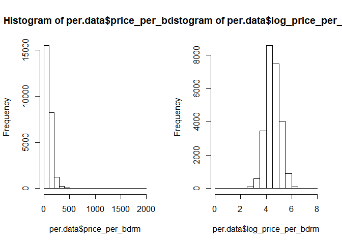

```r
per.data <- bnb.data %>%
  select(price, bedrooms, review_scores_rating) %>%
  filter(is.na(review_scores_rating)==FALSE & bedrooms>0) %>%
  mutate(price_per_bdrm = price/bedrooms,
         log_price_per_bdrm = log(price_per_bdrm))

# Ideally the distribution of price_per_bdrm should be really tight
par(mfrow = c(1, 2))
hist(per.data$price_per_bdrm)
hist(per.data$log_price_per_bdrm)
```

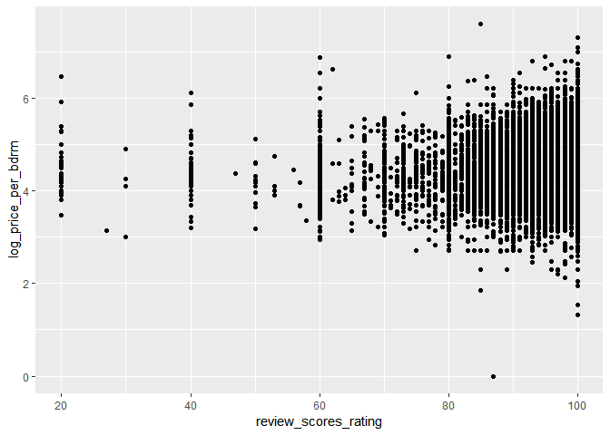

```r
# do the graph
ggplot(per.data,aes(x = review_scores_rating, y = log_price_per_bdrm)) +
  geom_point()
```

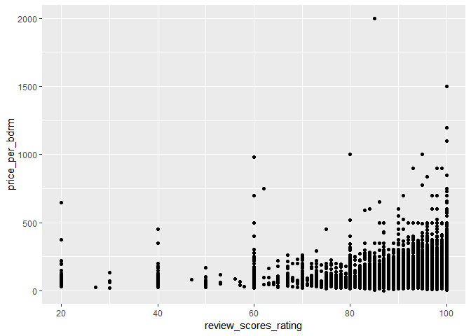

```r
ggplot(per.data,aes(x = review_scores_rating, y = price_per_bdrm)) +
  geom_point()
```

# A. Brand new section! Differences across cities.

While all the data come from 6 giant cities, as we already know, Ashley insists that conditions in east and west coast (and midwest) are totally different. So let explore a little bit!

First see general (log-)price distributions across cities. The difference is not quiet big.

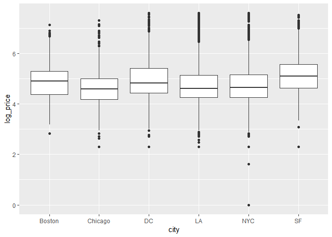

```r
ggplot(bnb.data, aes(x = city, y = log_price)) +
  geom_boxplot()
```

```r
# ggplot(bnb.data, aes(x = city, y = price)) +
#   geom_boxplot()
```

# B. Price with amenity?

Does AC matter? Does shampoo matter?

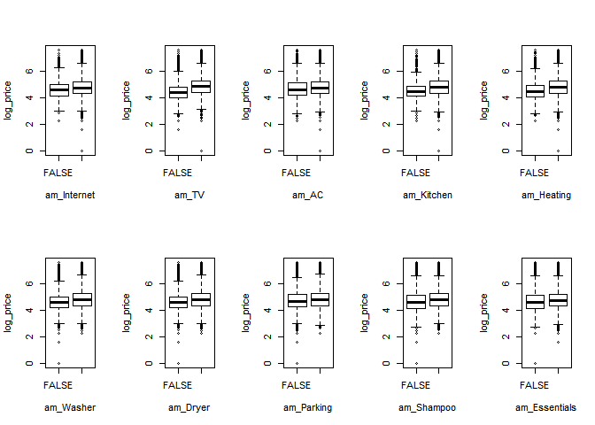

```r
shampoo.data <- bnb.data %>%
  select(log_price, starts_with("am_"))

par(mfrow = c(2, 5))
for (i in 2:11){
  plot(shampoo.data[,1] ~ as.factor(shampoo.data[,i]),
        xlab = colnames(shampoo.data)[i], ylab = colnames(shampoo.data)[1])
}
```